# Early-Season Crop Yield Prediction via XGBoost and Rolling Window Forward Validation

The R package **stcCropYield** implements a number of model training procedures to build trained prediction models for early-season crop yield (parcel-level) prediction for the province of Manitoba, using parcel-level NDVI and CARS-level weather measurement time series as predictor variables.

This vignette demonstrates how to use the function **stcCropYield::rollingWindowForwardValidation(.)** to train a crop yield prediction model, following the *rolling window forward validation* protocol, using XGBoost as the underlying prediction technique.

First, load the **stcCropYield** R package.

```r
library(stcCropYield)
```

Next, we generate a synthetic data set in the form of a single data frame that has the structure expected by **stcCropYield::rollingWindowForwardValidation(…)**:

```r
set.seed(13);

n.ecoregions    <-   3;
n.crops         <-   5;
n.predictors    <-   7;
avg.n.parcels   <- 100;
min.num.parcels <-  50;

DF.synthetic <- stcCropYield::getData.synthetic(
    years         = seq(2011,2020),
    n.ecoregions  = n.ecoregions,
    n.crops       = n.crops,
    n.predictors  = n.predictors,
    avg.n.parcels = avg.n.parcels
    )
```

```
#> INFO [2020-09-11 00:12:26] getData.synthetic(): starts
#> INFO [2020-09-11 00:12:26] getData.synthetic(): synthetic data generation begins
#> INFO [2020-09-11 00:12:26] getData.synthetic(): synthetic data generation complete
#> INFO [2020-09-11 00:12:26] getData.synthetic(): dim(DF.output) = c(3160,13)
#> INFO [2020-09-11 00:12:26] getData.synthetic(): exits
```

We examine the structure of the data frame DF.synthetic

```r
str(DF.synthetic)
```

```
#> 'data.frame':    3160 obs. of  13 variables:
#>  $ my_year          : int  2011 2011 2011 2011 2011 2011 2011 2011 2011 2011 ...
#>  $ my_ecoregion     : chr  "er01" "er01" "er01" "er01" ...
#>  $ my_parcelID      : chr  "O5x0Zls2" "estZaMMa" "rg8XgW5c" "1SKdQPuo" ...
#>  $ my_crop          : chr  "crop2" "crop4" "crop2" "crop3" ...
#>  $ my_harvested_area: num  0.911 0.866 0.876 0.987 0.842 ...
#>  $ my_yield         : num  3255 5430 3173 3735 5460 ...
#>  $ x1               : num  51.7 51.3 50.5 53 52.6 ...
#>  $ x2               : num  54.6 50.9 51.3 50.1 51 ...
#>  $ x3               : num  52.1 50.7 51.1 52.6 50.7 ...
#>  $ x4               : num  50.5 50.5 50.8 52.7 51.2 ...
#>  $ x5               : num  50.4 54.6 52.1 53.4 52.1 ...
#>  $ x6               : num  54.4 51.3 50.2 52.5 51 ...
#>  $ x7               : num  53 51 51.5 51.9 51.3 ...
```

The data frame DF.synthetic has 3160 rows and 13 columns.

Each row corresponds to a (reference year, parcel).

As the input data frame to the function **stcCropYield::rollingWindowForwardValidation** it must contain the following mandatory columns with the expected data types (while column names and ordering do NOT matter):

- a numeric column with non-negative integers indicating the reference year (in case of DF.synthetic, **my_year**)
- a character column indicating the ecoregion (**my_ecoregion**)
- a character column indicating the crop type (**my_crop**)
- numeric column with non-negative values indicating the harvested area (**my_harvested_area**).  
  The usual physical unit for harvested area is *acre*.
- numeric column with non-negative values indicating crop yield (**my_yield**).  
  The usual physical unit for crop yield is *number of bushels per acre*.
- a collection of numeric columns of predictor variables (in case of DF.synthetic, **x1**, **x2**, … , **x7**).  
  In practice, these could include (but are not limited to) the weekly NDVI measurements, the weekly (or monthly) weather measurements, and their derived variables (e.g. rolling averages, maxima, emerging week, etc).  
  There is no limit of the number of predictor variables (apart from computer memory).

Here are the first few rows of DF.synthetic:

```r
knitr::kable(head(DF.synthetic), align = "c")
```

| my_year | my_ecoregion | my_parcelID | my_crop | my_harvested_area | my_yield | x1 | x2 | x3 | x4 | x5 | x6 | x7 |
| --- | --- | --- | --- | --- | --- | --- | --- | --- | --- | --- | --- | --- |
| 2011 | er01 | O5x0Zls2 | crop2 | 0.9112761 | 3254.617 | 51.67967 | 54.63676 | 52.14911 | 50.49486 | 50.43189 | 54.42619 | 53.04606 |
| 2011 | er01 | estZaMMa | crop4 | 0.8659068 | 5429.650 | 51.27181 | 50.88402 | 50.71195 | 50.47563 | 54.55729 | 51.26950 | 50.97602 |
| 2011 | er01 | rg8XgW5c | crop2 | 0.8757078 | 3172.672 | 50.45606 | 51.32327 | 51.06778 | 50.82223 | 52.14724 | 50.21111 | 51.53625 |
| 2011 | er01 | 1SKdQPuo | crop3 | 0.9867353 | 3734.582 | 52.99712 | 50.13383 | 52.64371 | 52.65247 | 53.40529 | 52.54268 | 51.88366 |
| 2011 | er01 | X6S3l5bE | crop4 | 0.8419331 | 5459.608 | 52.59288 | 50.96012 | 50.67618 | 51.23589 | 52.14408 | 50.95938 | 51.27770 |
| 2011 | er01 | xbdu9Kjg | crop2 | 0.9767458 | 3200.034 | 50.08776 | 52.42352 | 52.24441 | 50.33277 | 53.66410 | 51.17684 | 50.59762 |

```r
(predictor.colnames <- grep(x = colnames(DF.synthetic), pattern = "x[0-9]*", value = TRUE))
```

```
#> [1] "x1" "x2" "x3" "x4" "x5" "x6" "x7"
```

```r
stcCropYield::rollingWindowForwardValidation(
    training.window      = 2,
    validation.window    = 3,
    DF.input             = DF.synthetic,
    year                 = "my_year",
    ecoregion            = "my_ecoregion",
    crop                 = "my_crop",
    response.variable    = "my_yield",
    harvested.area       = "my_harvested_area",
    predictors           = predictor.colnames,
    min.num.parcels      = min.num.parcels,
    learner              = "xgboost_multiphase",
    by.variables.phase01 = c("my_ecoregion","my_crop"),
    by.variables.phase02 = c("my_crop"),
    by.variables.phase03 = c("my_ecoregion"),
    search.grid = list(
        alpha  = c(1,12,23),
        lambda = c(1,12,23)
        ),
    output.directory = "rwFV",
    log.threshold    = logger::ERROR,
    suppress.child.process.graphics = TRUE
    )
```

```
#> INFO [2020-09-11 00:12:26] rollingWindowForwardValidation(): All output and log files are written to: /Users/kennethchu/Work/github/paradisepilot/crop-yield/101-package-stcCropYield/code/rwFV
#> NULL
```

We examine the contents in the output direcotry *rwFV*

```r
list.files("rwFV")
```

```
#> [1] "010-predictions"
#> [2] "020-performance-metrics"
#> [3] "030-mock-productions"
#> [4] "production-model-RY2021-xgboost_multiphase_9.RData"
#> [5] "rollingWindowForwardValidation.log"
```

The output directory *rwFV* contains:

- three sub-directories:
  - 010-predictions
  - 020-performance-metrics
  - 030-mock-productions
- one RData file: **production-model-RY2021-xgboost_multiphase_9.RData**
- one log file: **rollingWindowForwardValidation.log**

The sub-directory **rwFV/010-predictions** contains the (hyperparameter,year)-specific parcel-level predictions as well as rolled up values to the levels of (ecoregion,crop), crop and ecoregion.

The sub-directory **rwFV/020-performance-metrics** contains the computed performance metrics according to the aforementioned predictions.

The RData file **production-model-RY2021-xgboost_multiphase_9.RData** contains the final trained model that can be deployed in the next production cycle.

## Contents of **rwFV/010-predictions**

```r
list.files(file.path("rwFV","010-predictions"))
```

```
#>  [1] "learner-metadata.json"    "xgboost_multiphase_1"
#>  [3] "xgboost_multiphase_1.log" "xgboost_multiphase_2"
#>  [5] "xgboost_multiphase_2.log" "xgboost_multiphase_3"
#>  [7] "xgboost_multiphase_3.log" "xgboost_multiphase_4"
#>  [9] "xgboost_multiphase_4.log" "xgboost_multiphase_5"
#> [11] "xgboost_multiphase_5.log" "xgboost_multiphase_6"
#> [13] "xgboost_multiphase_6.log" "xgboost_multiphase_7"
#> [15] "xgboost_multiphase_7.log" "xgboost_multiphase_8"
#> [17] "xgboost_multiphase_8.log" "xgboost_multiphase_9"
#> [19] "xgboost_multiphase_9.log"
```

- **learner-metadata.json**  
  JSON file contains metadata about the 9 hyperparameter configurations being evaluated
- **xgboost_multiphase_1**, … , **xgboost_multiphase_9**  
  Sub-folders each containing parcel-level prediction results corresponding to one of hyperparameter configurations being evaluated
- **xgboost_multiphase_1.log**, … , **xgboost_multiphase_9.log**  
  log files during the fitting/predicting process for the hyperparameter configurations being evaluated

The file **rwFV/010-predictions/learner-metadata.json** contains the specifications of each hyperparameter configuration in the search grid. We can see its first 100 lines below:

```
#> {
#>   "xgboost_multiphase_1": {
#>     "learner": ["xgboost_multiphase"],
#>     "year": ["my_year"],
#>     "ecoregion": ["my_ecoregion"],
#>     "crop": ["my_crop"],
#>     "response_variable": ["my_yield"],
#>     "harvested_area": ["my_harvested_area"],
#>     "predictors": ["x1", "x2", "x3", "x4", "x5", "x6", "x7"],
#>     "min_num_parcels": [50],
#>     "by_variables_phase01": ["my_ecoregion", "my_crop"],
#>     "by_variables_phase02": ["my_crop"],
#>     "by_variables_phase03": ["my_ecoregion"],
#>     "hyperparameters": {
#>       "alpha": [1],
#>       "lambda": [1],
#>       "verbose": [2],
#>       "print_every_n": [10],
#>       "nrounds": [500]
#>     }
#>   },
#>   "xgboost_multiphase_2": {
#>     "learner": ["xgboost_multiphase"],
#>     "year": ["my_year"],
#>     "ecoregion": ["my_ecoregion"],
#>     "crop": ["my_crop"],
#>     "response_variable": ["my_yield"],
#>     "harvested_area": ["my_harvested_area"],
#>     "predictors": ["x1", "x2", "x3", "x4", "x5", "x6", "x7"],
#>     "min_num_parcels": [50],
#>     "by_variables_phase01": ["my_ecoregion", "my_crop"],
#>     "by_variables_phase02": ["my_crop"],
#>     "by_variables_phase03": ["my_ecoregion"],
#>     "hyperparameters": {
#>       "alpha": [12],
#>       "lambda": [1],
#>       "verbose": [2],
#>       "print_every_n": [10],
#>       "nrounds": [500]
#>     }
```

[output cut: 45 more lines]

```
#>     "crop": ["my_crop"],
#>     "response_variable": ["my_yield"],
#>     "harvested_area": ["my_harvested_area"],
#>     "predictors": ["x1", "x2", "x3", "x4", "x5", "x6", "x7"],
#>     "min_num_parcels": [50],
#>     "by_variables_phase01": ["my_ecoregion", "my_crop"],
#>     "by_variables_phase02": ["my_crop"],
#>     "by_variables_phase03": ["my_ecoregion"],
#>     "hyperparameters": {
#>       "alpha": [12],
#>       "lambda": [12],
#>       "verbose": [2],
#>       "print_every_n": [10],
#>       "nrounds": [500]
#>     }
```

Directory structure of **rwFV/010-predictions/xgboost_multiphase_1**

```
#> rwFV/010-predictions/xgboost_multiphase_1
#> ├── 2013
#> │   ├── plot-predictions-crop.png
#> │   ├── plot-predictions-region-crop.png
#> │   ├── plot-predictions-region.png
#> │   ├── predictions-xgboost_multiphase_1-crop.csv
#> │   ├── predictions-xgboost_multiphase_1-parcel.RData
#> │   ├── predictions-xgboost_multiphase_1-province.csv
#> │   ├── predictions-xgboost_multiphase_1-region-crop.csv
#> │   └── predictions-xgboost_multiphase_1-region.csv
#> ├── 2014
#> │   ├── plot-predictions-crop.png
#> │   ├── plot-predictions-region-crop.png
#> │   ├── plot-predictions-region.png
#> │   ├── predictions-xgboost_multiphase_1-crop.csv
#> │   ├── predictions-xgboost_multiphase_1-parcel.RData
#> │   ├── predictions-xgboost_multiphase_1-province.csv
#> │   ├── predictions-xgboost_multiphase_1-region-crop.csv
#> │   └── predictions-xgboost_multiphase_1-region.csv
#> ├── 2015
#> │   ├── plot-predictions-crop.png
#> │   ├── plot-predictions-region-crop.png
#> │   ├── plot-predictions-region.png
#> │   ├── predictions-xgboost_multiphase_1-crop.csv
#> │   ├── predictions-xgboost_multiphase_1-parcel.RData
#> │   ├── predictions-xgboost_multiphase_1-province.csv
#> │   ├── predictions-xgboost_multiphase_1-region-crop.csv
#> │   └── predictions-xgboost_multiphase_1-region.csv
#> ├── 2016
#> │   ├── plot-predictions-crop.png
#> │   ├── plot-predictions-region-crop.png
#> │   ├── plot-predictions-region.png
#> │   ├── predictions-xgboost_multiphase_1-crop.csv
#> │   ├── predictions-xgboost_multiphase_1-parcel.RData
#> │   ├── predictions-xgboost_multiphase_1-province.csv
#> │   ├── predictions-xgboost_multiphase_1-region-crop.csv
#> │   └── predictions-xgboost_multiphase_1-region.csv
#> ├── 2017
#> │   ├── plot-predictions-crop.png
#> │   ├── plot-predictions-region-crop.png
```

[output cut: 18 more lines]

```
#> │   ├── plot-predictions-region.png
#> │   ├── predictions-xgboost_multiphase_1-crop.csv
#> │   ├── predictions-xgboost_multiphase_1-parcel.RData
#> │   ├── predictions-xgboost_multiphase_1-province.csv
#> │   ├── predictions-xgboost_multiphase_1-region-crop.csv
#> │   └── predictions-xgboost_multiphase_1-region.csv
#> └── 2020
#>     ├── plot-predictions-crop.png
#>     ├── plot-predictions-region-crop.png
#>     ├── plot-predictions-region.png
#>     ├── predictions-xgboost_multiphase_1-crop.csv
#>     ├── predictions-xgboost_multiphase_1-parcel.RData
#>     ├── predictions-xgboost_multiphase_1-province.csv
#>     ├── predictions-xgboost_multiphase_1-region-crop.csv
#>     └── predictions-xgboost_multiphase_1-region.csv
```

```r
DF.parcel.2013 <- readRDS( file.path("rwFV","010-predictions","xgboost_multiphase_1","2013","predictions-xgboost_multiphase_1-parcel.RData") )
knitr::kable(head(DF.parcel.2013), align = "c")
```

| my_year | my_ecoregion | my_parcelID | my_crop | my_harvested_area | my_yield | x1 | x2 | x3 | x4 | x5 | x6 | x7 | predicted_response_phase01 | predicted_response_phase02 | predicted_response_phase03 | predicted_response | phase | actual_production | predicted_production |
| --- | --- | --- | --- | --- | --- | --- | --- | --- | --- | --- | --- | --- | --- | --- | --- | --- | --- | --- | --- |
| 2013 | er01 | O5x0Zls2 | crop4 | 0.8037264 | 3792.503 | 55.08838 | 50.95647 | 50.27136 | 50.20820 | 54.48835 | 51.37697 | 50.99690 | 4868.665 | 3911.468 | 3929.986 | 4868.665 | 1 | 3048.135 | 3913.075 |
| 2013 | er01 | estZaMMa | crop4 | 0.9581056 | 3746.666 | 51.49887 | 50.24656 | 50.39754 | 50.21447 | 51.41990 | 52.40467 | 51.47055 | 4814.410 | 3899.773 | 3902.966 | 4814.410 | 1 | 3589.702 | 4612.713 |
| 2013 | er01 | rg8XgW5c | crop3 | 0.8390235 | 4361.551 | 50.99882 | 50.89193 | 52.08955 | 51.23172 | 53.40212 | 52.72379 | 50.28874 | 3970.271 | 4088.607 | 3920.936 | 3970.271 | 1 | 3659.444 | 3331.151 |
| 2013 | er01 | 1SKdQPuo | crop3 | 0.8540885 | 4335.197 | 51.09430 | 53.66247 | 50.38165 | 50.56355 | 50.71312 | 50.58631 | 51.15906 | 3994.106 | 4103.516 | 3925.741 | 3994.106 | 1 | 3702.642 | 3411.320 |
| 2013 | er01 | X6S3l5bE | crop3 | 0.8814032 | 4306.302 | 50.54311 | 52.83163 | 50.51703 | 50.66547 | 50.44194 | 50.50251 | 50.87600 | 3977.190 | 4084.257 | 3914.648 | 3977.190 | 1 | 3795.589 | 3505.508 |
| 2013 | er01 | xbdu9Kjg | crop4 | 0.8395363 | 3741.106 | 51.68470 | 52.22192 | 51.72481 | 50.09896 | 50.50966 | 50.43258 | 51.26332 | 4858.756 | 3890.312 | 3938.918 | 4858.756 | 1 | 3140.794 | 4079.102 |

```r
DF.parcel.2013.gt01 <- DF.parcel.2013[DF.parcel.2013[,'phase'] > 1,]
knitr::kable(DF.parcel.2013.gt01, align = "c")
```

|  | my_year | my_ecoregion | my_parcelID | my_crop | my_harvested_area | my_yield | x1 | x2 | x3 | x4 | x5 | x6 | x7 | predicted_response_phase01 | predicted_response_phase02 | predicted_response_phase03 | predicted_response | phase | actual_production | predicted_production |
| --- | --- | --- | --- | --- | --- | --- | --- | --- | --- | --- | --- | --- | --- | --- | --- | --- | --- | --- | --- | --- |
| 18 | 2013 | er01 | PC87TiIs | crop5 | 0.9283328 | 2057.886 | 50.68033 | 50.55324 | 51.81692 | 50.78842 | 50.24496 | 50.81895 | 50.61915 | NA | NA | 3920.720 | 3920.720 | 3 | 1910.403 | 3639.733 |
| 23 | 2013 | er01 | qNe1Hx6n | crop1 | 0.8791424 | 3580.088 | 51.39608 | 50.47422 | 52.11562 | 51.22209 | 50.65142 | 51.53357 | 52.65895 | NA | NA | 3922.692 | 3922.692 | 3 | 3147.407 | 3448.605 |
| 84 | 2013 | er01 | kTf4wW1w | crop1 | 0.8058951 | 3548.418 | 51.33398 | 51.01423 | 50.59913 | 50.26559 | 51.13173 | 52.49963 | 50.73946 | NA | NA | 3922.175 | 3922.175 | 3 | 2859.653 | 3160.862 |
| 92 | 2013 | er01 | 1zY19ieZ | crop1 | 0.8997723 | 3604.517 | 50.65918 | 52.69122 | 50.06081 | 53.33537 | 50.49460 | 52.43138 | 50.56051 | NA | NA | 3940.864 | 3940.864 | 3 | 3243.245 | 3545.880 |
| 96 | 2013 | er01 | ZXS7H4TM | crop1 | 0.9736356 | 3588.204 | 56.25264 | 50.37394 | 50.14160 | 50.58034 | 51.00476 | 50.64184 | 50.66255 | NA | NA | 3980.176 | 3980.176 | 3 | 3493.603 | 3875.241 |
| 105 | 2013 | er01 | ddhXQwHk | crop1 | 0.8750981 | 3628.071 | 50.34363 | 50.86980 | 50.23934 | 51.30140 | 58.06622 | 50.69591 | 50.74679 | NA | NA | 3803.560 | 3803.560 | 3 | 3174.918 | 3328.488 |
| 108 | 2013 | er02 | 4lRZUqgk | crop5 | 0.8471414 | 3331.009 | 54.48270 | 51.31002 | 56.18918 | 57.71844 | 52.09199 | 50.43260 | 51.42488 | NA | NA | 3473.302 | 3473.302 | 3 | 2821.836 | 2942.378 |
| 130 | 2013 | er02 | vkdZm11E | crop5 | 0.8001994 | 3191.655 | 50.99419 | 51.23504 | 53.52884 | 51.75302 | 50.47859 | 50.50800 | 50.69630 | NA | NA | 3426.037 | 3426.037 | 3 | 2553.961 | 2741.513 |
| 146 | 2013 | er02 | 5QDU6K78 | crop5 | 0.8142450 | 3208.676 | 50.70068 | 50.45613 | 51.01385 | 50.41923 | 51.41687 | 51.56263 | 51.22244 | NA | NA | 3421.252 | 3421.252 | 3 | 2612.648 | 2785.738 |
| 183 | 2013 | er02 | LRFC49mN | crop5 | 0.8826923 | 3197.600 | 50.61808 | 51.03366 | 50.68877 | 52.55364 | 50.80855 | 51.44051 | 50.64190 | NA | NA | 3432.463 | 3432.463 | 3 | 2822.497 | 3029.809 |
| 187 | 2013 | er02 | nNpApVBy | crop1 | 0.9873199 | 4357.772 | 51.32717 | 52.81600 | 53.59526 | 50.49453 | 50.69278 | 50.62884 | 51.19787 | NA | NA | 3457.983 | 3457.983 | 3 | 4302.515 | 3414.135 |
| 216 | 2013 | er03 | mKeI0aKg | crop5 | 0.8473678 | 3826.183 | 50.66227 | 50.87900 | 50.25653 | 51.00837 | 53.61530 | 51.10162 | 51.25235 | NA | NA | 3236.503 | 3236.503 | 3 | 3242.184 | 2742.508 |
| 217 | 2013 | er03 | 9KBQRDq0 | crop1 | 0.8277046 | 2340.607 | 51.32118 | 51.48688 | 54.41246 | 51.65519 | 63.69353 | 50.21276 | 50.24323 | NA | NA | 3256.258 | 3256.258 | 3 | 1937.332 | 2695.219 |
| 221 | 2013 | er03 | RQGEh8Vu | crop1 | 0.8243734 | 2261.300 | 50.54771 | 50.19133 | 50.82664 | 51.60744 | 50.55326 | 50.31647 | 55.14758 | NA | NA | 3187.292 | 3187.292 | 3 | 1864.155 | 2627.519 |
| 222 | 2013 | er03 | Rag27QiW | crop3 | 0.8913220 | 3280.048 | 54.79584 | 51.29862 | 50.08962 | 50.91488 | 50.90231 | 50.32107 | 51.16753 | NA | 4121.291 | 3338.553 | 4121.291 | 2 | 2923.579 | 3673.397 |
| 233 | 2013 | er03 | STEbkMYR | crop5 | 0.8869101 | 3841.847 | 50.97813 | 50.93068 | 51.37226 | 50.16218 | 50.58363 | 52.34980 | 53.15024 | NA | NA | 3245.553 | 3245.553 | 3 | 3407.373 | 2878.514 |
| 235 | 2013 | er03 | NJXcTzth | crop3 | 0.9752913 | 3301.652 | 51.03805 | 50.97111 | 50.19239 | 50.62579 | 50.84806 | 52.80855 | 50.09605 | NA | 4060.213 | 3284.637 | 4060.213 | 2 | 3220.073 | 3959.891 |
| 238 | 2013 | er03 | gsUhYH16 | crop3 | 0.8200883 | 3248.360 | 52.64369 | 50.48161 | 50.15462 | 50.33754 | 50.58999 | 51.19361 | 50.39296 | NA | 4076.318 | 3300.691 | 4076.318 | 2 | 2663.942 | 3342.941 |
| 243 | 2013 | er03 | fsiixPOB | crop3 | 0.8861259 | 3364.786 | 50.93097 | 52.12455 | 51.84991 | 50.17548 | 59.68592 | 50.44627 | 51.49431 | NA | 4122.295 | 3230.277 | 4122.295 | 2 | 2981.624 | 3652.872 |
| 247 | 2013 | er03 | iEEUZcfF | crop3 | 0.9588727 | 3293.112 | 51.11550 | 50.30746 | 50.67979 | 50.90331 | 50.49303 | 55.43052 | 51.50062 | NA | 4043.779 | 3259.832 | 4043.779 | 2 | 3157.676 | 3877.470 |
| 248 | 2013 | er03 | KUCLVmIy | crop3 | 0.9510934 | 3358.366 | 50.55039 | 50.77713 | 56.89610 | 51.32506 | 51.25525 | 50.61257 | 54.81528 | NA | 4105.334 | 3278.616 | 4105.334 | 2 | 3194.119 | 3904.556 |
| 250 | 2013 | er03 | vTaex6IP | crop5 | 0.9524346 | 3883.248 | 50.84892 | 50.51079 | 52.42717 | 54.67606 | 51.14749 | 51.65316 | 51.79014 | NA | NA | 3283.702 | 3283.702 | 3 | 3698.540 | 3127.511 |
| 263 | 2013 | er03 | SHgxApAJ | crop3 | 0.9629194 | 3356.654 | 50.03095 | 50.48916 | 50.67250 | 56.13426 | 51.82015 | 54.79942 | 50.43616 | NA | 4052.283 | 3267.858 | 4052.283 | 2 | 3232.187 | 3902.022 |
| 264 | 2013 | er03 | O1LHPDx0 | crop3 | 0.8857350 | 3303.298 | 53.64884 | 50.43961 | 50.61152 | 53.70730 | 51.28774 | 51.49182 | 50.69387 | NA | 4103.518 | 3323.903 | 4103.518 | 2 | 2925.847 | 3634.629 |
| 265 | 2013 | er03 | 0u6cxbCR | crop3 | 0.8307897 | 3306.456 | 53.57058 | 51.03155 | 51.61948 | 50.11871 | 50.60306 | 52.50818 | 51.22198 | NA | 4108.272 | 3331.161 | 4108.272 | 2 | 2746.969 | 3413.110 |
| 267 | 2013 | er03 | Eh0zsU9d | crop3 | 0.9746186 | 3430.674 | 52.96662 | 51.02997 | 53.75734 | 52.40328 | 51.47158 | 58.05393 | 53.01996 | NA | 4111.467 | 3317.206 | 4111.467 | 2 | 3343.599 | 4007.112 |
| 268 | 2013 | er03 | lKUw81oy | crop3 | 0.8518274 | 3353.860 | 51.29451 | 53.73456 | 52.56828 | 51.03699 | 52.68505 | 51.63867 | 52.50532 | NA | 4130.880 | 3313.494 | 4130.880 | 2 | 2856.910 | 3518.797 |
| 269 | 2013 | er03 | mwp3Fzgy | crop3 | 0.9491706 | 3380.263 | 58.65852 | 52.62819 | 51.02590 | 50.37738 | 52.65892 | 51.08497 | 54.49148 | NA | 4198.315 | 3369.924 | 4198.315 | 2 | 3208.446 | 3984.918 |
| 270 | 2013 | er03 | rsuu0L9P | crop3 | 0.9401526 | 3249.326 | 50.81800 | 51.69587 | 50.26179 | 50.90073 | 50.19343 | 50.44902 | 50.85888 | NA | 4067.465 | 3286.743 | 4067.465 | 2 | 3054.862 | 3824.038 |
| 271 | 2013 | er03 | syjsKas1 | crop3 | 0.9857146 | 3300.967 | 50.55634 | 50.38025 | 50.61825 | 52.76623 | 50.29139 | 53.45936 | 50.84362 | NA | 4045.687 | 3269.170 | 4045.687 | 2 | 3253.811 | 3987.893 |
| 273 | 2013 | er03 | qwl4lpcH | crop3 | 0.8271012 | 3275.800 | 52.82835 | 50.59176 | 50.42553 | 50.60552 | 51.83983 | 50.49464 | 51.02446 | NA | 4086.801 | 3289.591 | 4086.801 | 2 | 2709.419 | 3380.198 |
| 275 | 2013 | er03 | dJvxgJJ7 | crop3 | 0.8646081 | 3332.400 | 50.97470 | 51.20268 | 57.18753 | 52.43331 | 51.49847 | 50.64305 | 50.27710 | NA | 4148.302 | 3379.061 | 4148.302 | 2 | 2881.220 | 3586.655 |
| 276 | 2013 | er03 | CwgurtHX | crop3 | 0.8807695 | 3319.528 | 55.18835 | 52.37080 | 50.62564 | 50.66827 | 53.29255 | 52.02392 | 50.35533 | NA | 4159.381 | 3366.207 | 4159.381 | 2 | 2923.739 | 3663.456 |
| 277 | 2013 | er03 | OGCrC9kR | crop3 | 0.8220300 | 3332.247 | 51.89907 | 56.09778 | 51.40943 | 51.77216 | 50.43482 | 51.15055 | 51.86075 | NA | 4162.609 | 3380.754 | 4162.609 | 2 | 2739.207 | 3421.790 |
| 282 | 2013 | er03 | wuzvO3fs | crop3 | 0.9736771 | 3275.949 | 50.23975 | 50.69016 | 50.95884 | 54.19374 | 50.29729 | 50.98972 | 50.57670 | NA | 4058.126 | 3282.594 | 4058.126 | 2 | 3189.717 | 3951.305 |
| 285 | 2013 | er03 | qQLFSRXG | crop3 | 0.8902317 | 3282.304 | 53.05645 | 50.59245 | 50.67840 | 51.68229 | 50.37043 | 52.51614 | 50.24613 | NA | 4090.643 | 3325.459 | 4090.643 | 2 | 2922.011 | 3641.620 |
| 286 | 2013 | er03 | 3f6EKOKT | crop3 | 0.8870349 | 3266.415 | 50.54941 | 51.19098 | 50.95842 | 52.04631 | 51.46873 | 51.05250 | 50.65923 | NA | 4069.908 | 3279.641 | 4069.908 | 2 | 2897.424 | 3610.150 |
| 289 | 2013 | er03 | aAtdBv8a | crop3 | 0.8342476 | 3294.717 | 51.01226 | 53.42577 | 50.35768 | 51.05792 | 53.96462 | 50.42057 | 50.28969 | NA | 4115.615 | 3302.571 | 4115.615 | 2 | 2748.610 | 3433.442 |
| 290 | 2013 | er03 | e7ySHxsn | crop3 | 0.9671245 | 3280.717 | 51.29504 | 50.73886 | 53.48883 | 50.62787 | 50.45709 | 50.70311 | 51.24013 | NA | 4092.841 | 3312.645 | 4092.841 | 2 | 3172.862 | 3958.287 |
| 292 | 2013 | er03 | H81WRre7 | crop3 | 0.9624504 | 3337.192 | 50.63564 | 51.15578 | 51.66878 | 54.79212 | 50.42052 | 54.82010 | 52.13198 | NA | 4066.407 | 3280.549 | 4066.407 | 2 | 3211.882 | 3913.715 |
| 293 | 2013 | er03 | T77h5dog | crop3 | 0.8448427 | 3375.318 | 51.34282 | 50.30357 | 50.66837 | 51.06963 | 63.01217 | 51.41927 | 50.42789 | NA | 4104.350 | 3186.023 | 4104.350 | 2 | 2851.613 | 3467.530 |
| 302 | 2013 | er03 | Ov3s12jr | crop3 | 0.9229992 | 3296.820 | 51.36394 | 50.48495 | 50.37354 | 52.78770 | 53.61013 | 51.28204 | 50.86776 | NA | 4072.481 | 3256.246 | 4072.481 | 2 | 3042.962 | 3758.897 |
| 306 | 2013 | er03 | vN1WFAz8 | crop5 | 0.9023159 | 3926.993 | 50.63868 | 50.75378 | 51.93326 | 56.56018 | 53.32974 | 52.03092 | 52.00388 | NA | NA | 3262.483 | 3262.483 | 3 | 3543.388 | 2943.791 |
| 312 | 2013 | er03 | BzUZH8XF | crop3 | 0.9273093 | 3361.613 | 57.20378 | 51.27314 | 51.54516 | 54.70729 | 50.64379 | 50.36881 | 51.79473 | NA | 4177.358 | 3403.838 | 4177.358 | 2 | 3117.255 | 3873.703 |

```r
DF.parcel.2020 <- readRDS( file.path("rwFV","010-predictions","xgboost_multiphase_1","2020","predictions-xgboost_multiphase_1-parcel.RData") )
knitr::kable(head(DF.parcel.2020), align = "c")
```

| my_year | my_ecoregion | my_parcelID | my_crop | my_harvested_area | my_yield | x1 | x2 | x3 | x4 | x5 | x6 | x7 | predicted_response_phase01 | predicted_response_phase02 | predicted_response_phase03 | predicted_response | phase | actual_production | predicted_production |
| --- | --- | --- | --- | --- | --- | --- | --- | --- | --- | --- | --- | --- | --- | --- | --- | --- | --- | --- | --- |
| 2020 | er01 | O5x0Zls2 | crop4 | 0.8021164 | 3221.043 | 53.18443 | 52.17935 | 50.12839 | 50.97617 | 50.54352 | 51.54207 | 50.66934 | 2921.990 | 2985.528 | 3683.292 | 2921.990 | 1 | 2583.651 | 2343.776 |
| 2020 | er01 | estZaMMa | crop3 | 0.9505549 | 4070.624 | 51.91489 | 52.23846 | 50.40344 | 50.44447 | 50.80305 | 50.47036 | 59.73731 | 3760.189 | 3757.966 | 3670.339 | 3760.189 | 1 | 3869.352 | 3574.266 |
| 2020 | er01 | rg8XgW5c | crop4 | 0.8175796 | 3310.140 | 52.99797 | 61.67978 | 50.40558 | 50.05808 | 50.81099 | 50.71076 | 50.13229 | 3076.811 | 3033.800 | 3792.742 | 3076.811 | 1 | 2706.303 | 2515.538 |
| 2020 | er01 | 1SKdQPuo | crop4 | 0.8864002 | 3265.753 | 52.63042 | 50.42531 | 52.96523 | 50.55216 | 51.27734 | 50.36840 | 54.74686 | 2925.505 | 3013.970 | 3682.288 | 2925.505 | 1 | 2894.764 | 2593.168 |
| 2020 | er01 | X6S3l5bE | crop3 | 0.8733345 | 4146.092 | 52.52199 | 52.56644 | 50.15487 | 60.67989 | 50.35270 | 50.92761 | 50.40699 | 3836.454 | 3695.191 | 3682.266 | 3836.454 | 1 | 3620.925 | 3350.507 |
| 2020 | er01 | xbdu9Kjg | crop3 | 0.9962200 | 3976.293 | 50.19612 | 50.54678 | 52.13360 | 51.60023 | 50.18835 | 50.29950 | 50.42982 | 3782.255 | 3651.638 | 3662.308 | 3782.255 | 1 | 3961.262 | 3767.958 |

```r
DF.parcel.2020.phase02 <- DF.parcel.2020[DF.parcel.2020[,'phase'] > 1,]
knitr::kable(DF.parcel.2020.phase02, align = "c")
```

|  | my_year | my_ecoregion | my_parcelID | my_crop | my_harvested_area | my_yield | x1 | x2 | x3 | x4 | x5 | x6 | x7 | predicted_response_phase01 | predicted_response_phase02 | predicted_response_phase03 | predicted_response | phase | actual_production | predicted_production |
| --- | --- | --- | --- | --- | --- | --- | --- | --- | --- | --- | --- | --- | --- | --- | --- | --- | --- | --- | --- | --- |
| 18 | 2020 | er01 | PC87TiIs | crop1 | 0.9837903 | 5427.418 | 51.40044 | 52.28023 | 51.02938 | 50.19651 | 50.47867 | 50.46009 | 51.00582 | NA | NA | 3679.180 | 3679.180 | 3 | 5339.441 | 3619.542 |
| 22 | 2020 | er01 | SaeG80wT | crop1 | 0.9701049 | 5468.014 | 51.02198 | 51.14013 | 55.77622 | 50.29077 | 51.55502 | 50.29708 | 50.18121 | NA | NA | 3715.764 | 3715.764 | 3 | 5304.547 | 3604.681 |
| 45 | 2020 | er01 | BknxJYI2 | crop1 | 0.9635163 | 5450.878 | 51.83380 | 51.92638 | 50.12560 | 51.39804 | 51.25821 | 51.62709 | 50.24604 | NA | NA | 3682.084 | 3682.084 | 3 | 5252.010 | 3547.748 |
| 77 | 2020 | er01 | a4e4v57N | crop5 | 0.9452025 | 4013.153 | 50.33908 | 50.18313 | 56.51332 | 50.80963 | 51.56389 | 50.36682 | 51.11935 | NA | NA | 3708.711 | 3708.711 | 3 | 3793.243 | 3505.483 |
| 127 | 2020 | er02 | s6DNEvaQ | crop1 | 0.9675171 | 3742.603 | 51.47289 | 50.44698 | 50.97984 | 54.02260 | 50.28412 | 51.14903 | 50.30299 | NA | NA | 3333.700 | 3333.700 | 3 | 3621.033 | 3225.411 |
| 167 | 2020 | er02 | Qx5wmNvS | crop5 | 0.9473298 | 3471.230 | 52.70994 | 51.64902 | 50.93462 | 52.94165 | 51.25213 | 51.02205 | 50.25729 | NA | NA | 3344.421 | 3344.421 | 3 | 3288.399 | 3168.270 |
| 169 | 2020 | er02 | G7rCvoXr | crop1 | 0.9669248 | 3888.946 | 50.74594 | 50.55701 | 51.48194 | 57.93070 | 50.97428 | 54.08165 | 56.77378 | NA | NA | 3334.974 | 3334.974 | 3 | 3760.319 | 3224.669 |
| 187 | 2020 | er02 | nNpApVBy | crop1 | 0.8723145 | 3804.157 | 51.44510 | 51.72814 | 50.56007 | 57.39775 | 53.93372 | 51.62761 | 50.21883 | NA | NA | 3367.282 | 3367.282 | 3 | 3318.422 | 2937.329 |
| 204 | 2020 | er02 | fbQ6gWyc | crop5 | 0.9053606 | 3431.955 | 50.39833 | 50.68454 | 51.03641 | 50.37733 | 51.37504 | 51.33672 | 51.18568 | NA | NA | 3341.318 | 3341.318 | 3 | 3107.157 | 3025.098 |
| 218 | 2020 | er03 | 6R2fUjwP | crop5 | 0.9423048 | 4871.330 | 53.28913 | 50.81940 | 50.48036 | 55.32000 | 53.35923 | 50.95473 | 50.55808 | NA | NA | 3883.101 | 3883.101 | 3 | 4590.278 | 3659.065 |
| 219 | 2020 | er03 | CVFxXvya | crop1 | 0.9586819 | 1785.526 | 50.34041 | 57.93831 | 50.21602 | 51.01175 | 51.16453 | 50.99166 | 50.27555 | NA | NA | 3796.303 | 3796.303 | 3 | 1711.751 | 3639.447 |
| 241 | 2020 | er03 | Q5kog2oP | crop5 | 0.9725253 | 4801.859 | 51.29443 | 51.11751 | 50.26875 | 50.78298 | 50.83098 | 54.08388 | 51.32137 | NA | NA | 3729.577 | 3729.577 | 3 | 4669.929 | 3627.108 |
| 277 | 2020 | er03 | OGCrC9kR | crop1 | 0.8011048 | 1751.554 | 50.50527 | 50.17690 | 50.85395 | 50.16698 | 51.51809 | 50.38191 | 50.61581 | NA | NA | 3708.872 | 3708.872 | 3 | 1403.178 | 2971.195 |
| 278 | 2020 | er03 | wohGd6d0 | crop5 | 0.8162286 | 4829.093 | 50.63660 | 56.95832 | 50.41760 | 50.38745 | 52.69521 | 50.59098 | 50.59870 | NA | NA | 3779.990 | 3779.990 | 3 | 3941.644 | 3085.336 |
| 304 | 2020 | er03 | KE2rnt2q | crop1 | 0.9364130 | 1782.325 | 57.20750 | 53.85104 | 50.44592 | 52.09559 | 50.16581 | 50.18273 | 50.33500 | NA | NA | 3837.454 | 3837.454 | 3 | 1668.992 | 3593.442 |
| 314 | 2020 | er03 | IDyX5vO4 | crop1 | 0.8185087 | 1825.585 | 50.79687 | 50.96035 | 50.95561 | 51.59083 | 59.66304 | 50.30805 | 50.25178 | NA | NA | 3793.077 | 3793.077 | 3 | 1494.257 | 3104.667 |
| 316 | 2020 | er03 | gvcIVhsl | crop5 | 0.8787102 | 4881.762 | 51.76808 | 50.69621 | 54.93785 | 50.21559 | 51.68171 | 56.61492 | 50.58094 | NA | NA | 3725.170 | 3725.170 | 3 | 4289.654 | 3273.345 |

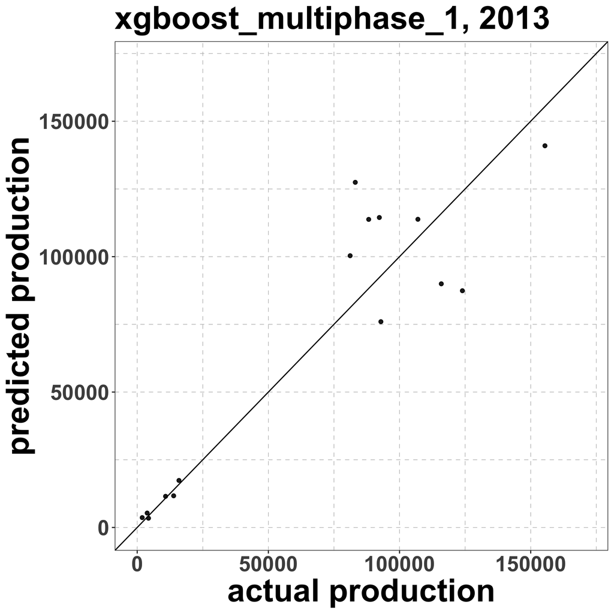

```r
knitr::include_graphics(
    path = file.path(
        "rwFV",
        "010-predictions",
        "xgboost_multiphase_1",
        "2013",
        "plot-predictions-region-crop.png"
        )
    )
```

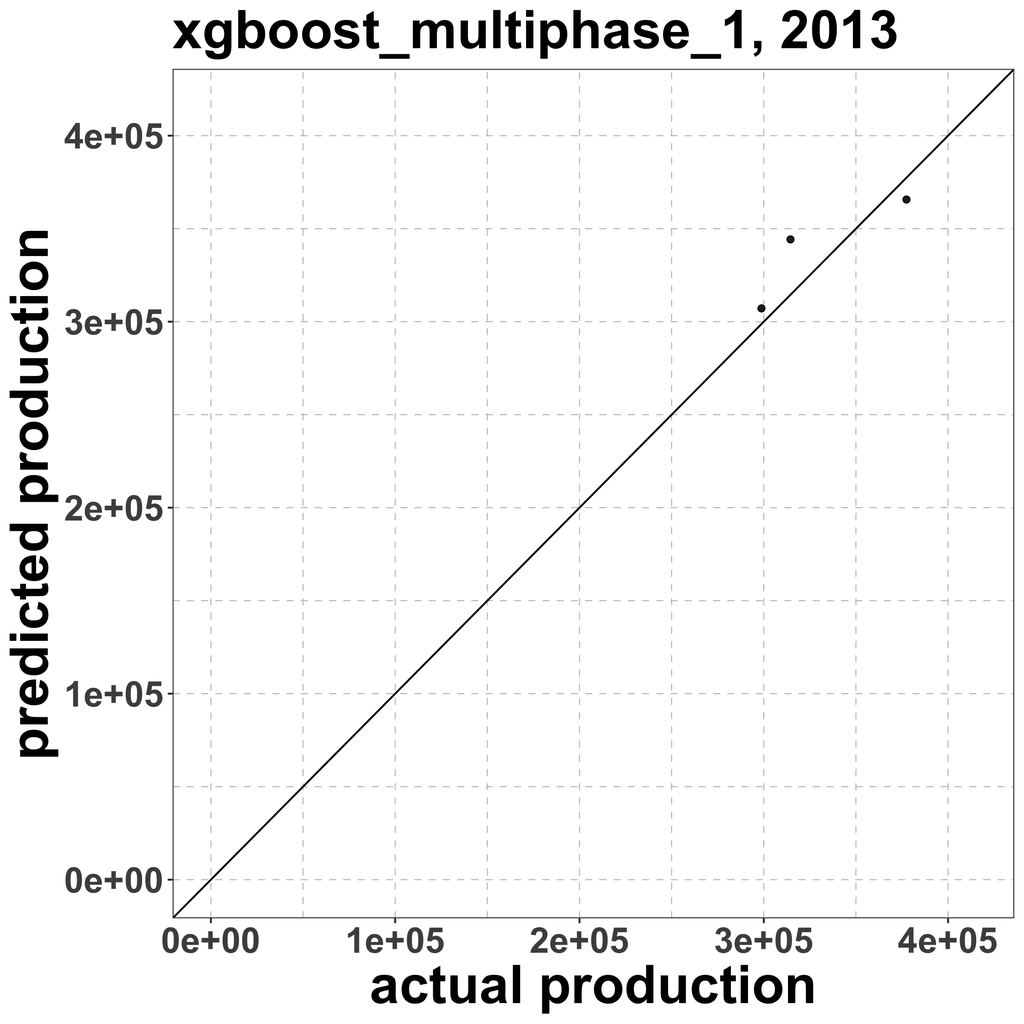

```r
knitr::include_graphics(
    path = file.path(
        "rwFV",
        "010-predictions",
        "xgboost_multiphase_1",
        "2013",
        "plot-predictions-region.png"
        )
    )
```

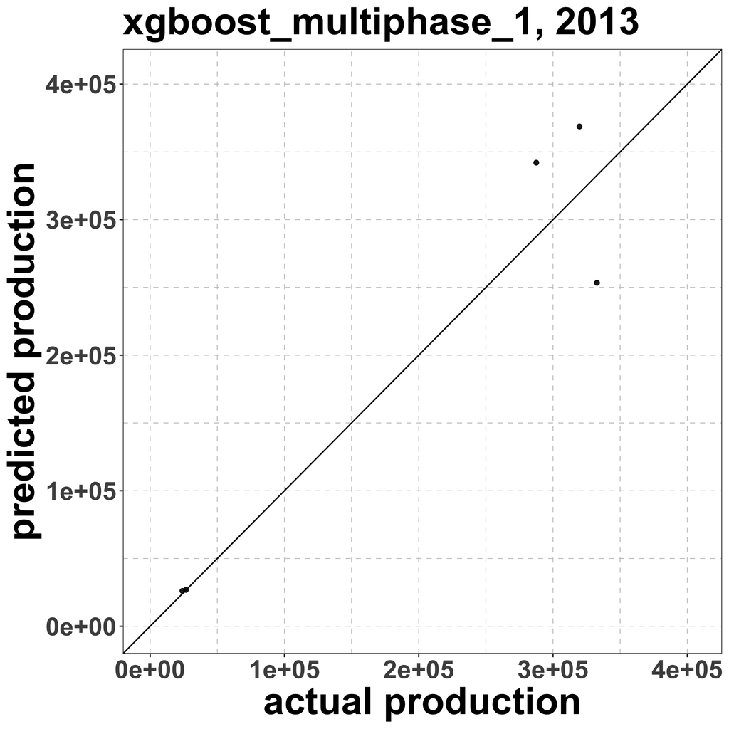

```r
knitr::include_graphics(
    path = file.path(
        "rwFV",
        "010-predictions",
        "xgboost_multiphase_1",
        "2013",
        "plot-predictions-crop.png"
        )
    )
```

```r
list.files(file.path("rwFV","020-performance-metrics"))
```

```
#> [1] "list-performance-metrics.RData"
#> [2] "metrics-xgboost_multiphase-model-year.csv"
```

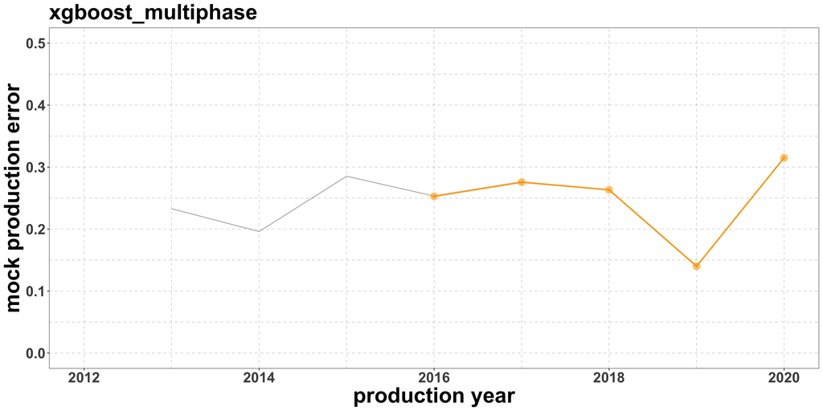

```r
knitr::include_graphics(
    path = file.path(
        "rwFV",
        "030-mock-productions",
        "plot-xgboost_multiphase-mockProdErr-vs-year.png"
        )
    )
```